# In-Class Notebook - Module 7: Classification

### Load Libraries and Data

```python
import pandas as pd
import numpy as np
import matplotlib.pyplot as plt
import warnings
warnings.filterwarnings("ignore")
```

```python
NANSE_df = pd.read_csv('Mod7_data.csv')
NANSE_df.head(20)
```

|  | store | week | high_med_gp | high_med_rev | high_med_units | high_med_gpm | size | region | promo_units_per | altbev_units_per | confect_units_per | salty_units_per | velocityA_units_per | velocityB_units_per | velocityC_units_per | velocityD_units_per | velocityNEW_units_per |
| --- | --- | --- | --- | --- | --- | --- | --- | --- | --- | --- | --- | --- | --- | --- | --- | --- | --- |
| 0 | 186 | 1 | 1 | 1 | 1 | 1 | 966 | ONTARIO | 0.219146 | 0.249135 | 0.354095 | 0.235294 | 0.589773 | 0.213379 | 0.081123 | 0.081892 | 0.0 |
| 1 | 186 | 2 | 1 | 1 | 1 | 0 | 966 | ONTARIO | 0.296960 | 0.271360 | 0.345280 | 0.226240 | 0.619200 | 0.201920 | 0.075520 | 0.076800 | 0.0 |
| 2 | 186 | 3 | 1 | 1 | 1 | 0 | 966 | ONTARIO | 0.294548 | 0.276263 | 0.365691 | 0.207447 | 0.615027 | 0.198138 | 0.076795 | 0.083777 | 0.0 |
| 3 | 186 | 4 | 1 | 1 | 1 | 0 | 966 | ONTARIO | 0.295549 | 0.287900 | 0.341099 | 0.232267 | 0.583102 | 0.210709 | 0.072670 | 0.101878 | 0.0 |
| 4 | 186 | 5 | 1 | 1 | 1 | 0 | 966 | ONTARIO | 0.290435 | 0.292522 | 0.359652 | 0.220870 | 0.609391 | 0.193739 | 0.079652 | 0.092174 | 0.0 |
| 5 | 186 | 6 | 1 | 1 | 1 | 0 | 966 | ONTARIO | 0.313286 | 0.282365 | 0.351342 | 0.225280 | 0.623174 | 0.205912 | 0.064220 | 0.078491 | 0.0 |
| 6 | 186 | 7 | 1 | 1 | 1 | 0 | 966 | ONTARIO | 0.324120 | 0.287595 | 0.331688 | 0.222442 | 0.624877 | 0.172425 | 0.082264 | 0.088516 | 0.0 |
| 7 | 186 | 8 | 1 | 1 | 1 | 0 | 966 | ONTARIO | 0.315353 | 0.286945 | 0.329716 | 0.235876 | 0.601341 | 0.212257 | 0.073412 | 0.089052 | 0.0 |
| 8 | 186 | 9 | 1 | 1 | 1 | 0 | 966 | ONTARIO | 0.280540 | 0.290089 | 0.333553 | 0.211064 | 0.571946 | 0.219295 | 0.081660 | 0.102733 | 0.0 |
| 9 | 186 | 10 | 1 | 1 | 1 | 0 | 966 | ONTARIO | 0.287163 | 0.304549 | 0.317010 | 0.203999 | 0.563315 | 0.222544 | 0.085772 | 0.093596 | 0.0 |
| 10 | 186 | 11 | 1 | 1 | 1 | 0 | 966 | ONTARIO | 0.340490 | 0.347534 | 0.308286 | 0.173767 | 0.562563 | 0.213016 | 0.084200 | 0.113049 | 0.0 |
| 11 | 186 | 12 | 1 | 1 | 1 | 0 | 966 | ONTARIO | 0.309172 | 0.293787 | 0.324852 | 0.206805 | 0.585503 | 0.206213 | 0.091716 | 0.089349 | 0.0 |
| 12 | 186 | 13 | 1 | 1 | 1 | 0 | 966 | ONTARIO | 0.325199 | 0.311936 | 0.303448 | 0.187003 | 0.573210 | 0.208223 | 0.091777 | 0.106366 | 0.0 |
| 13 | 186 | 14 | 1 | 1 | 1 | 0 | 966 | ONTARIO | 0.289859 | 0.323152 | 0.279475 | 0.204032 | 0.561393 | 0.233659 | 0.093769 | 0.090715 | 0.0 |
| 14 | 186 | 15 | 1 | 1 | 1 | 0 | 966 | ONTARIO | 0.277764 | 0.353098 | 0.259538 | 0.194654 | 0.554313 | 0.241312 | 0.087485 | 0.100365 | 0.0 |
| 15 | 186 | 16 | 1 | 1 | 1 | 0 | 966 | ONTARIO | 0.284580 | 0.342687 | 0.288265 | 0.200397 | 0.609977 | 0.209184 | 0.078515 | 0.085034 | 0.0 |
| 16 | 186 | 17 | 1 | 1 | 1 | 0 | 966 | ONTARIO | 0.270621 | 0.331976 | 0.245418 | 0.199338 | 0.557536 | 0.226069 | 0.082994 | 0.114817 | 0.0 |
| 17 | 186 | 18 | 1 | 1 | 1 | 1 | 966 | ONTARIO | 0.267116 | 0.396496 | 0.207817 | 0.193261 | 0.551752 | 0.214286 | 0.095418 | 0.116712 | 0.0 |
| 18 | 186 | 19 | 1 | 1 | 1 | 0 | 966 | ONTARIO | 0.230937 | 0.350451 | 0.218487 | 0.226891 | 0.572985 | 0.196078 | 0.107999 | 0.109244 | 0.0 |
| 19 | 186 | 20 | 1 | 1 | 1 | 1 | 966 | ONTARIO | 0.221535 | 0.393299 | 0.174691 | 0.223813 | 0.593038 | 0.229343 | 0.086858 | 0.076122 | 0.0 |

```python
NANSE_df.describe()
```

|  | store | week | high_med_gp | high_med_rev | high_med_units | high_med_gpm | size | promo_units_per | altbev_units_per | confect_units_per | salty_units_per | velocityA_units_per | velocityB_units_per | velocityC_units_per | velocityD_units_per | velocityNEW_units_per |
| --- | --- | --- | --- | --- | --- | --- | --- | --- | --- | --- | --- | --- | --- | --- | --- | --- |
| count | 10071.000000 | 10071.000000 | 10071.000000 | 10071.000000 | 10071.000000 | 10071.000000 | 10071.000000 | 10071.000000 | 10071.000000 | 10071.000000 | 10071.000000 | 10071.000000 | 10071.000000 | 10071.000000 | 10071.000000 | 10071.000000 |
| mean | 36561.765267 | 26.468573 | 0.499652 | 0.499652 | 0.499454 | 0.463906 | 949.594380 | 0.350606 | 0.405471 | 0.270573 | 0.173669 | 0.608591 | 0.216868 | 0.080087 | 0.079177 | 0.004608 |
| std | 28160.998011 | 14.995523 | 0.500025 | 0.500025 | 0.500025 | 0.498720 | 46.458451 | 0.063659 | 0.064860 | 0.050079 | 0.031275 | 0.044064 | 0.020620 | 0.013308 | 0.030015 | 0.007350 |
| min | 186.000000 | 1.000000 | 0.000000 | 0.000000 | 0.000000 | 0.000000 | 890.000000 | 0.105263 | 0.202983 | 0.000000 | 0.000000 | 0.442882 | 0.140998 | 0.000000 | 0.000000 | 0.000000 |
| 25% | 12981.000000 | 13.000000 | 0.000000 | 0.000000 | 0.000000 | 0.000000 | 916.000000 | 0.304639 | 0.357474 | 0.234898 | 0.152000 | 0.574411 | 0.203151 | 0.070783 | 0.055326 | 0.000000 |
| 50% | 35288.000000 | 26.000000 | 0.000000 | 0.000000 | 0.000000 | 0.000000 | 943.000000 | 0.345122 | 0.401932 | 0.264481 | 0.171625 | 0.610689 | 0.216172 | 0.079937 | 0.070453 | 0.000000 |
| 75% | 59552.000000 | 39.000000 | 1.000000 | 1.000000 | 1.000000 | 1.000000 | 972.000000 | 0.392868 | 0.449058 | 0.301154 | 0.192771 | 0.642769 | 0.230003 | 0.089293 | 0.102649 | 0.007963 |
| max | 92589.000000 | 52.000000 | 1.000000 | 1.000000 | 1.000000 | 1.000000 | 1163.000000 | 0.579677 | 0.725000 | 0.474147 | 0.368421 | 0.750000 | 0.313475 | 0.148649 | 0.216365 | 0.055623 |

```python
NANSE_df.info()
```

```
<class 'pandas.core.frame.DataFrame'>
RangeIndex: 10071 entries, 0 to 10070
Data columns (total 17 columns):
 #   Column                 Non-Null Count  Dtype
---  ------                 --------------  -----
 0   store                  10071 non-null  int64
 1   week                   10071 non-null  int64
 2   high_med_gp            10071 non-null  int64
 3   high_med_rev           10071 non-null  int64
 4   high_med_units         10071 non-null  int64
 5   high_med_gpm           10071 non-null  int64
 6   size                   10071 non-null  int64
 7   region                 10071 non-null  object
 8   promo_units_per        10071 non-null  float64
 9   altbev_units_per       10071 non-null  float64
 10  confect_units_per      10071 non-null  float64
 11  salty_units_per        10071 non-null  float64
 12  velocityA_units_per    10071 non-null  float64
 13  velocityB_units_per    10071 non-null  float64
 14  velocityC_units_per    10071 non-null  float64
 15  velocityD_units_per    10071 non-null  float64
 16  velocityNEW_units_per  10071 non-null  float64
dtypes: float64(9), int64(7), object(1)
memory usage: 1.3+ MB
```

## Logistic Regression

### Prepare the Data

1. Create indicator variables for categorical variables (for logistic regression we drop the first level)
2. Split data into training and testing data

```python
NANSE_df_prep = pd.get_dummies(NANSE_df, drop_first=True, dtype=int)
NANSE_df_prep.info()
```

```
<class 'pandas.core.frame.DataFrame'>
RangeIndex: 10071 entries, 0 to 10070
Data columns (total 19 columns):
 #   Column                 Non-Null Count  Dtype
---  ------                 --------------  -----
 0   store                  10071 non-null  int64
 1   week                   10071 non-null  int64
 2   high_med_gp            10071 non-null  int64
 3   high_med_rev           10071 non-null  int64
 4   high_med_units         10071 non-null  int64
 5   high_med_gpm           10071 non-null  int64
 6   size                   10071 non-null  int64
 7   promo_units_per        10071 non-null  float64
 8   altbev_units_per       10071 non-null  float64
 9   confect_units_per      10071 non-null  float64
 10  salty_units_per        10071 non-null  float64
 11  velocityA_units_per    10071 non-null  float64
 12  velocityB_units_per    10071 non-null  float64
 13  velocityC_units_per    10071 non-null  float64
 14  velocityD_units_per    10071 non-null  float64
 15  velocityNEW_units_per  10071 non-null  float64
 16  region_ONTARIO         10071 non-null  int64
 17  region_QUEBEC          10071 non-null  int64
 18  region_WEST            10071 non-null  int64
dtypes: float64(9), int64(10)
memory usage: 1.5 MB
```

```python
from sklearn.model_selection import train_test_split

x_logit = NANSE_df_prep[['size', 'region_ONTARIO', 'region_QUEBEC', 'region_WEST', 'promo_units_per', 'altbev_units_per',
                         'confect_units_per', 'salty_units_per', 'velocityA_units_per', 'velocityB_units_per',
                         'velocityC_units_per', 'velocityD_units_per', 'velocityNEW_units_per']]
y_logit = NANSE_df_prep[['high_med_units']]

x_train, x_test, y_train, y_test = train_test_split(x_logit, y_logit, test_size=0.4, random_state=42)
```

### Fit the Model

1. Run the logit model
2. Display the summary for the model

```python
import statsmodels.api as sm

log_reg = sm.Logit(y_train, x_train).fit()
```

```
Optimization terminated successfully.
         Current function value: 0.522799
         Iterations 6
```

```python
log_reg.summary2()
```

| Model: | Logit | Method: | MLE |
| --- | --- | --- | --- |
| Dependent Variable: | high_med_units | Pseudo R-squared: | 0.246 |
| Date: | 2025-12-07 22:36 | AIC: | 6343.5041 |
| No. Observations: | 6042 | BIC: | 6430.6884 |
| Df Model: | 12 | Log-Likelihood: | -3158.8 |
| Df Residuals: | 6029 | LL-Null: | -4187.6 |
| Converged: | 1.0000 | LLR p-value: | 0.0000 |
| No. Iterations: | 6.0000 | Scale: | 1.0000 |

|  | Coef. | Std.Err. | z | P>\|z\| | [0.025 | 0.975] |
| --- | --- | --- | --- | --- | --- | --- |
| size | 0.0164 | 0.0009 | 18.8578 | 0.0000 | 0.0147 | 0.0181 |
| region_ONTARIO | 0.2695 | 0.1895 | 1.4220 | 0.1550 | -0.1019 | 0.6408 |
| region_QUEBEC | 1.6107 | 0.2066 | 7.7972 | 0.0000 | 1.2058 | 2.0155 |
| region_WEST | 1.3149 | 0.1822 | 7.2150 | 0.0000 | 0.9577 | 1.6720 |
| promo_units_per | -6.4992 | 0.5940 | -10.9413 | 0.0000 | -7.6634 | -5.3349 |
| altbev_units_per | 5.8539 | 1.0356 | 5.6525 | 0.0000 | 3.8241 | 7.8837 |
| confect_units_per | -5.6872 | 1.0950 | -5.1935 | 0.0000 | -7.8334 | -3.5409 |
| salty_units_per | 23.2817 | 1.5496 | 15.0245 | 0.0000 | 20.2446 | 26.3188 |
| velocityA_units_per | -17.1944 | 1.3300 | -12.9278 | 0.0000 | -19.8012 | -14.5876 |
| velocityB_units_per | -23.6936 | 1.7618 | -13.4484 | 0.0000 | -27.1466 | -20.2405 |
| velocityC_units_per | -12.8043 | 2.9027 | -4.4111 | 0.0000 | -18.4935 | -7.1150 |
| velocityD_units_per | -29.4756 | 2.0766 | -14.1941 | 0.0000 | -33.5457 | -25.4056 |
| velocityNEW_units_per | -39.5597 | 5.3580 | -7.3833 | 0.0000 | -50.0612 | -29.0583 |

**Questions to discuss:**

1. What do the coefficients mean here? Specifically, explain the meaning of the coefficient on “promo_units_per”. Don't get too technical, just say whether it helps or hurts profitability.
2. What does the p-value mean?

### Make Predictions for the Testing Data

For each row in the testing data we want to make a prediction for whether our dependent variable was 0 or 1.

```python
from sklearn.linear_model import LogisticRegression

lr = LogisticRegression(class_weight = 'balanced')
lr.fit(x_train, y_train.values.ravel())
lr_predictions = lr.predict(x_test)
FullTestLRDf = pd.concat([x_test, y_test], axis=1)
FullTestLRDf['Predicted_Values'] = lr_predictions
FullTestLRDf.head()
```

|  | size | region_ONTARIO | region_QUEBEC | region_WEST | promo_units_per | altbev_units_per | confect_units_per | salty_units_per | velocityA_units_per | velocityB_units_per | velocityC_units_per | velocityD_units_per | velocityNEW_units_per | high_med_units | Predicted_Values |
| --- | --- | --- | --- | --- | --- | --- | --- | --- | --- | --- | --- | --- | --- | --- | --- |
| 1121 | 898 | 1 | 0 | 0 | 0.468799 | 0.527691 | 0.220749 | 0.115445 | 0.662246 | 0.198128 | 0.074883 | 0.060842 | 0.000000 | 0 | 0 |
| 318 | 948 | 1 | 0 | 0 | 0.458022 | 0.223608 | 0.385702 | 0.226101 | 0.590191 | 0.223608 | 0.052369 | 0.095594 | 0.000000 | 0 | 0 |
| 8298 | 1034 | 0 | 0 | 1 | 0.298527 | 0.375678 | 0.267511 | 0.225252 | 0.601447 | 0.235849 | 0.093047 | 0.064616 | 0.005040 | 1 | 1 |
| 1149 | 917 | 0 | 0 | 1 | 0.284978 | 0.357143 | 0.307806 | 0.207658 | 0.538292 | 0.221649 | 0.100884 | 0.111929 | 0.000000 | 0 | 1 |
| 33 | 966 | 1 | 0 | 0 | 0.347918 | 0.384248 | 0.245293 | 0.195174 | 0.680986 | 0.203129 | 0.065500 | 0.044816 | 0.005569 | 1 | 0 |

### Create Confusion Matrix to Evaluate the Logistic Regression Model

We will create a confusion matrix and print out our accuracy measures for our logistic regression model.

```python
from sklearn import metrics

cm_lr = metrics.confusion_matrix(y_test, lr_predictions)

print(cm_lr)
```

```
[[1470  584]
 [ 534 1441]]
```

```python
true_negative, false_positive, false_negative, true_positive = cm_lr.ravel()

print(f"True Positives (TP), : {true_positive}")
print(f"True Negatives (TN), Rejection: {true_negative}")
print(f"False Positives (FP), Type I Error: {false_positive}")
print(f"False Negatives (FN), Type II Error: {false_negative}")
```

```
True Positives (TP), : 1441
True Negatives (TN), Rejection: 1470
False Positives (FP), Type I Error: 584
False Negatives (FN), Type II Error: 534
```

```python
Accuracy = metrics.accuracy_score(y_test, lr_predictions)
Precision = metrics.precision_score(y_test, lr_predictions)
Sensitivity = metrics.recall_score(y_test, lr_predictions)
Specificity = metrics.recall_score(y_test, lr_predictions, pos_label=0)
Negative_Predictive_Value = metrics.precision_score(y_test, lr_predictions, pos_label=0)

print(f'Accuracy (TP+TN)/(TP+TN+FP+FN): {Accuracy}')
print(f'Precision/Positive Predictive Value TP/(TP+FP): {Precision}')
print(f'Sensitivity/Recall/Hit Rate/True Positive Rate TP/(TP+FN): {Sensitivity}')
print(f'Specificity/Selectivity/True Negative Rate TN/(TN+FP): {Specificity}')
print(f'Negative Predictive Value TN/(TN+FN): {Negative_Predictive_Value}')
```

```
Accuracy (TP+TN)/(TP+TN+FP+FN): 0.722511789525937
Precision/Positive Predictive Value TP/(TP+FP): 0.711604938271605
Sensitivity/Recall/Hit Rate/True Positive Rate TP/(TP+FN): 0.7296202531645569
Specificity/Selectivity/True Negative Rate TN/(TN+FP): 0.7156767283349562
Negative Predictive Value TN/(TN+FN): 0.7335329341317365
```

## Decision Trees (for Classification)

### Prepare the Data

1. Create indicator variables for categorical variables
2. Split data into training and testing data

```python
NANSE_df_prep_dtc = pd.get_dummies(NANSE_df, dtype=int)

x_dtc = NANSE_df_prep_dtc[['size', 'region_ATLANTIC', 'region_ONTARIO', 'region_QUEBEC', 'region_WEST', 'promo_units_per',
                       'altbev_units_per', 'confect_units_per', 'salty_units_per', 'velocityA_units_per',
                       'velocityB_units_per', 'velocityC_units_per', 'velocityD_units_per', 'velocityNEW_units_per']]
y_dtc = NANSE_df_prep_dtc[['high_med_gp']]

x_train_dtc, x_test_dtc, y_train_dtc, y_test_dtc = train_test_split(x_dtc, y_dtc, test_size=0.4, random_state=42)
```

### Fit the Model

```python
from sklearn.tree import DecisionTreeClassifier

dtc = DecisionTreeClassifier(class_weight = 'balanced', ccp_alpha=.004, random_state=42)

dtc = dtc.fit(x_train_dtc, y_train_dtc)
```

### Visualizing the Decision Tree Algorithm

Now that we have our model `dtc`, we can visualize it using the code below.

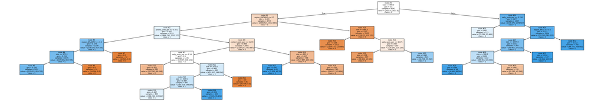

```python
from sklearn.tree import plot_tree

plt.figure(figsize=(48,8))
plot_tree(dtc,
          filled=True,
          feature_names=x_train_dtc.columns,
          class_names=['0','1'],
          node_ids = True);
```

### Make Predictions for the Testing Data

For each row in the testing data we want to make a prediction for whether our dependent variable was 0 or 1.

```python
dtc_predictions = dtc.predict(x_test_dtc)
FullTestDtcDf = pd.concat([x_test_dtc, y_test_dtc], axis=1)
FullTestDtcDf['Predicted_Values'] = dtc_predictions
FullTestDtcDf.head()
```

|  | size | region_ATLANTIC | region_ONTARIO | region_QUEBEC | region_WEST | promo_units_per | altbev_units_per | confect_units_per | salty_units_per | velocityA_units_per | velocityB_units_per | velocityC_units_per | velocityD_units_per | velocityNEW_units_per | high_med_gp | Predicted_Values |
| --- | --- | --- | --- | --- | --- | --- | --- | --- | --- | --- | --- | --- | --- | --- | --- | --- |
| 1121 | 898 | 0 | 1 | 0 | 0 | 0.468799 | 0.527691 | 0.220749 | 0.115445 | 0.662246 | 0.198128 | 0.074883 | 0.060842 | 0.000000 | 0 | 0 |
| 318 | 948 | 0 | 1 | 0 | 0 | 0.458022 | 0.223608 | 0.385702 | 0.226101 | 0.590191 | 0.223608 | 0.052369 | 0.095594 | 0.000000 | 0 | 0 |
| 8298 | 1034 | 0 | 0 | 0 | 1 | 0.298527 | 0.375678 | 0.267511 | 0.225252 | 0.601447 | 0.235849 | 0.093047 | 0.064616 | 0.005040 | 1 | 1 |
| 1149 | 917 | 0 | 0 | 0 | 1 | 0.284978 | 0.357143 | 0.307806 | 0.207658 | 0.538292 | 0.221649 | 0.100884 | 0.111929 | 0.000000 | 0 | 1 |
| 33 | 966 | 0 | 1 | 0 | 0 | 0.347918 | 0.384248 | 0.245293 | 0.195174 | 0.680986 | 0.203129 | 0.065500 | 0.044816 | 0.005569 | 1 | 1 |

### Create Confusion Matrix to Evaluate the Decision Tree Model

We will create a confusion matrix and print out our accuracy measures for our decision tree model.

```python
from sklearn import metrics

cm_dtc = metrics.confusion_matrix(y_test_dtc, dtc_predictions)

print(cm_dtc)
```

```
[[1564  503]
 [ 317 1645]]
```

```python
true_negative, false_positive, false_negative, true_positive = cm_dtc.ravel()

print(f"True Positives (TP), : {true_positive}")
print(f"True Negatives (TN), Rejection: {true_negative}")
print(f"False Positives (FP), Type I Error: {false_positive}")
print(f"False Negatives (FN), Type II Error: {false_negative}")
```

```
True Positives (TP), : 1645
True Negatives (TN), Rejection: 1564
False Positives (FP), Type I Error: 503
False Negatives (FN), Type II Error: 317
```

```python
Accuracy = metrics.accuracy_score(y_test, dtc_predictions)
Precision = metrics.precision_score(y_test, dtc_predictions)
Sensitivity = metrics.recall_score(y_test, dtc_predictions)
Specificity = metrics.recall_score(y_test, dtc_predictions, pos_label=0)
Negative_Predictive_Value = metrics.precision_score(y_test, dtc_predictions, pos_label=0)

print(f'Accuracy (TP+TN)/(TP+TN+FP+FN): {Accuracy}')
print(f'Precision/Positive Predictive Value TP/(TP+FP): {Precision}')
print(f'Sensitivity/Recall/Hit Rate/True Positive Rate TP/(TP+FN): {Sensitivity}')
print(f'Specificity/Selectivity/True Negative Rate TN/(TN+FP): {Specificity}')
print(f'Negative Predictive Value TN/(TN+FN): {Negative_Predictive_Value}')
```

```
Accuracy (TP+TN)/(TP+TN+FP+FN): 0.7818317200297841
Precision/Positive Predictive Value TP/(TP+FP): 0.75512104283054
Sensitivity/Recall/Hit Rate/True Positive Rate TP/(TP+FN): 0.8212658227848101
Specificity/Selectivity/True Negative Rate TN/(TN+FP): 0.7439143135345667
Negative Predictive Value TN/(TN+FN): 0.8123338649654439
```

## KNN - K Nearest Neighbors

### Prepare the Data

1. Create indicator variables for categorical variables
2. Split data into training and testing data
3. Scale or standardize variables

```python
NANSE_df_prep_knn = pd.get_dummies(NANSE_df, dtype=int)

x_knn = NANSE_df_prep_knn[['size', 'region_ATLANTIC', 'region_ONTARIO', 'region_QUEBEC', 'region_WEST', 'promo_units_per',
                       'altbev_units_per', 'confect_units_per', 'salty_units_per', 'velocityA_units_per',
                       'velocityB_units_per', 'velocityC_units_per', 'velocityD_units_per', 'velocityNEW_units_per']]
y_knn = NANSE_df_prep_knn[['high_med_gp']]

x_train_knn, x_test_knn, y_train_knn, y_test_knn = train_test_split(x_knn, y_knn, test_size=0.4, random_state=42)
```

```python
from sklearn.preprocessing import StandardScaler

sc = StandardScaler().fit(x_train_knn)
x_train_sc = sc.transform(x_train_knn)
x_test_sc = sc.transform(x_test_knn)
```

**Question to answer:**

Why do we standardize?

### Make Predictions for the Testing Data

```python
from sklearn.neighbors import KNeighborsClassifier
knn = KNeighborsClassifier(n_neighbors=100)

knn.fit(x_train_sc, np.ravel(y_train_knn))
```

```
KNeighborsClassifier(n_neighbors=100)
```

Next, we will make predictions with our KNN algorithm.

```python
knn_predictions = knn.predict(x_test_sc)
FullTestKnnDf = pd.concat([x_test_knn, y_test_knn], axis=1)
FullTestKnnDf['Predicted_Values'] = knn_predictions
FullTestKnnDf.head()
```

|  | size | region_ATLANTIC | region_ONTARIO | region_QUEBEC | region_WEST | promo_units_per | altbev_units_per | confect_units_per | salty_units_per | velocityA_units_per | velocityB_units_per | velocityC_units_per | velocityD_units_per | velocityNEW_units_per | high_med_gp | Predicted_Values |
| --- | --- | --- | --- | --- | --- | --- | --- | --- | --- | --- | --- | --- | --- | --- | --- | --- |
| 1121 | 898 | 0 | 1 | 0 | 0 | 0.468799 | 0.527691 | 0.220749 | 0.115445 | 0.662246 | 0.198128 | 0.074883 | 0.060842 | 0.000000 | 0 | 0 |
| 318 | 948 | 0 | 1 | 0 | 0 | 0.458022 | 0.223608 | 0.385702 | 0.226101 | 0.590191 | 0.223608 | 0.052369 | 0.095594 | 0.000000 | 0 | 0 |
| 8298 | 1034 | 0 | 0 | 0 | 1 | 0.298527 | 0.375678 | 0.267511 | 0.225252 | 0.601447 | 0.235849 | 0.093047 | 0.064616 | 0.005040 | 1 | 1 |
| 1149 | 917 | 0 | 0 | 0 | 1 | 0.284978 | 0.357143 | 0.307806 | 0.207658 | 0.538292 | 0.221649 | 0.100884 | 0.111929 | 0.000000 | 0 | 1 |
| 33 | 966 | 0 | 1 | 0 | 0 | 0.347918 | 0.384248 | 0.245293 | 0.195174 | 0.680986 | 0.203129 | 0.065500 | 0.044816 | 0.005569 | 1 | 0 |

### Create Confusion Matrix to Evaluate the KNN Algorithm

We will create a confusion matrix and print out our accuracy measures for our KNN Algorithm.

```python
from sklearn import metrics

cm_knn = metrics.confusion_matrix(y_test_knn, knn_predictions)

print(cm_knn)
```

```
[[1549  518]
 [ 404 1558]]
```

```python
true_negative, false_positive, false_negative, true_positive = cm_knn.ravel()

print(f"True Positives (TP), : {true_positive}")
print(f"True Negatives (TN), Rejection: {true_negative}")
print(f"False Positives (FP), Type I Error: {false_positive}")
print(f"False Negatives (FN), Type II Error: {false_negative}")
```

```
True Positives (TP), : 1558
True Negatives (TN), Rejection: 1549
False Positives (FP), Type I Error: 518
False Negatives (FN), Type II Error: 404
```

```python
Accuracy = metrics.accuracy_score(y_test, knn_predictions)
Precision = metrics.precision_score(y_test, knn_predictions)
Sensitivity = metrics.recall_score(y_test, knn_predictions)
Specificity = metrics.recall_score(y_test, knn_predictions, pos_label=0)
Negative_Predictive_Value = metrics.precision_score(y_test, knn_predictions, pos_label=0)

print(f'Accuracy (TP+TN)/(TP+TN+FP+FN): {Accuracy}')
print(f'Precision/Positive Predictive Value TP/(TP+FP): {Precision}')
print(f'Sensitivity/Recall/Hit Rate/True Positive Rate TP/(TP+FN): {Sensitivity}')
print(f'Specificity/Selectivity/True Negative Rate TN/(TN+FP): {Specificity}')
print(f'Negative Predictive Value TN/(TN+FN): {Negative_Predictive_Value}')
```

```
Accuracy (TP+TN)/(TP+TN+FP+FN): 0.7540332588731695
Precision/Positive Predictive Value TP/(TP+FP): 0.7369942196531792
Sensitivity/Recall/Hit Rate/True Positive Rate TP/(TP+FN): 0.7746835443037975
Specificity/Selectivity/True Negative Rate TN/(TN+FP): 0.7341772151898734
Negative Predictive Value TN/(TN+FN): 0.7721454173067076
```

KNN= 0.734

5. Highest Metric: Logistic regression= Neg Predictive Value 0.734

Decision Tree=Sensitivity 0.82

KNN= Sensitivity 0.77

6. a) For the weekly dashboard, I'd go with the decision tree. It has the most true above-median weeks with a sensitivity of 0.821, which is really what matters when you're trying to identify stores that need attention. Logistic regression is solid, but it misses more weeks. KNN just doesn't perform as well overall. Plus, the decision tree gives you actual rules you can explain to store managers. b) For figuring out what actually drives successful weeks, logistic regression may be the best model. It shows you exactly which variables matter and by how much—you get coefficients and p-values that tell the story. KNN is more for making one decision and receiving one answer and while the decision tree is easy to read, it only shows you a handful of splits. Logistic regression lets NANSE see the full picture: which factors boost performance, which ones hurt, and their relative impact. That's the kind of insight you need for strategic decisions.
7. a) Naive Bayes

   b) It is a probabilistic classifier that's built on Bayes' Theorem. The model makes one key assumption: that all your features are independent from each other, which is why it's called 'naive.' This assumption lets model train really fast and handle lots of features well, especially for things like text classification, even when you don't have tons of data. The problem is that features are rarely independent in real life. When your variables are actually related to each other, Naive Bayes starts to lose accuracy and the probability estimates it gives you aren't very reliable. Naive Bayes is quicker and easier to work with, but it doesn't handle complex relationships between variables as well. It's easier to understand than KNN, but it can't capture feature interactions like decision trees can.